# Module 3 Assignment Solutions

### Test assumptions

```r
# normality
salary_cost_join %>%
  filter(type %in% c("Private", "Public")) %>%
  drop_na(early_career_pay, mid_career_pay, type) %>% # remove NAs
  group_by(type) %>% # test by sex
  shapiro_test(early_career_pay,
               mid_career_pay) # test for normality
```

```
## # A tibble: 4 × 4
##   type    variable         statistic        p
##   <chr>   <chr>                <dbl>    <dbl>
## 1 Private early_career_pay     0.951 4.83e-11
## 2 Private mid_career_pay       0.951 3.95e-11
## 3 Public  early_career_pay     0.954 1.28e- 7
## 4 Public  mid_career_pay       0.952 6.50e- 8
```

```r
# constant variance early_career_pay
salary_cost_join %>%
  filter(type %in% c("Private", "Public")) %>%
  drop_na(early_career_pay, mid_career_pay, type) %>% # remove NAs
  levene_test(early_career_pay ~ type) # test for constant variance
```

```
## # A tibble: 1 × 4
##     df1   df2 statistic         p
##   <int> <int>     <dbl>     <dbl>
## 1     1   725      18.2 0.0000223
```

```r
# constant variance
salary_cost_join %>%
  filter(type %in% c("Private", "Public")) %>%
  drop_na(early_career_pay, mid_career_pay, type) %>% # remove NAs
  levene_test(mid_career_pay ~ type) # test for constant variance
```

```
## # A tibble: 1 × 4
##     df1   df2 statistic          p
##   <int> <int>     <dbl>      <dbl>
## 1     1   725      20.6 0.00000663
```

Not normal and no constant variance. Non-parametric it is.

### Plot

#### Using stat_compare_means()

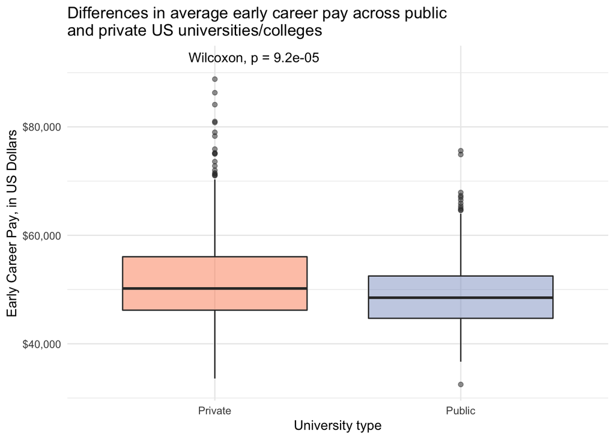

```r
salary_cost_join %>%
  drop_na(type, early_career_pay) %>% # drop missing values for variables to plot
  filter(type %in% c("Private", "Public")) %>% # only private and public unis
  ggplot(aes(x = type, y = early_career_pay, fill = type)) +
  geom_boxplot(alpha = 0.5) + # boxplot
  scale_y_continuous(labels = dollar) + # convert y-axis labels to dollar format
  scale_fill_manual(values = c("#fc8d62", "#8da0cb")) + # pick colors
  stat_compare_means(label.y = 92000) + # run stats, indicate label position
  theme_minimal() +
  theme(legend.position = "none") +
  labs(x = "University type",
       y = "Early Career Pay, in US Dollars",
       title = "Differences in average early career pay across public \nand private US universities/colleges")
```

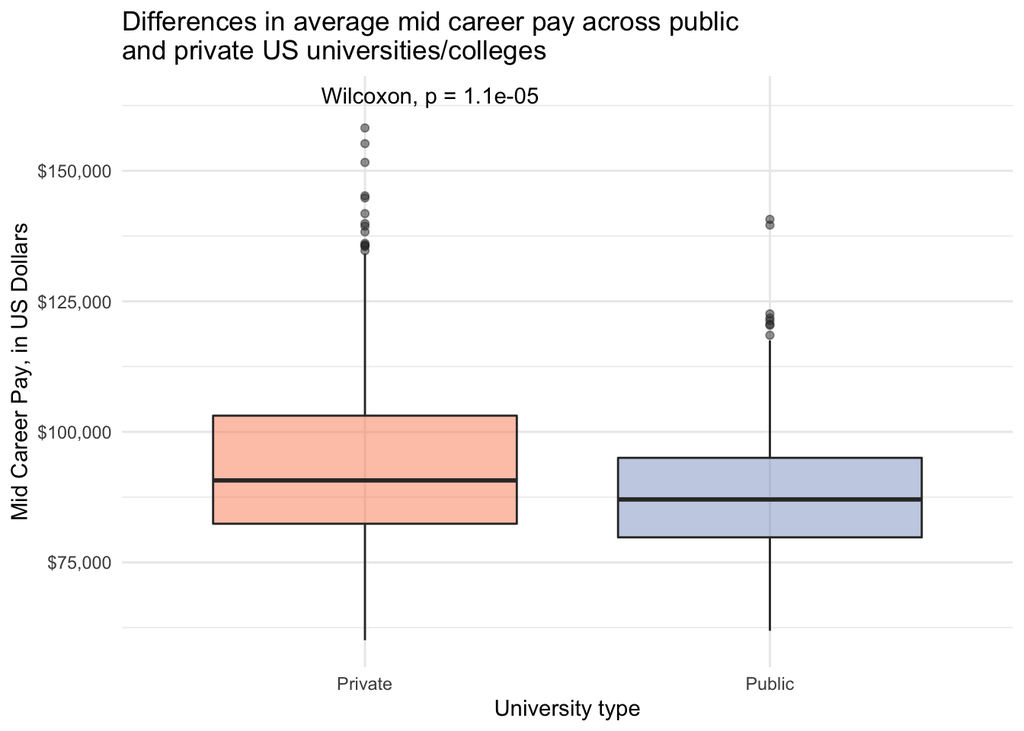

```r
salary_cost_join %>%
  drop_na(type, mid_career_pay) %>%
  filter(type %in% c("Private", "Public")) %>%
  ggplot(aes(x = type, y = mid_career_pay, fill = type)) +
  geom_boxplot(alpha = 0.5) +
  scale_y_continuous(labels = dollar) +
  scale_fill_manual(values = c("#fc8d62", "#8da0cb")) +
  stat_compare_means(label.y = 163000) +
  theme_minimal() +
  theme(legend.position = "none") +
  labs(x = "University type",
       y = "Mid Career Pay, in US Dollars",
       title = "Differences in average mid career pay across public \nand private US universities/colleges")
```

#### With annotate()

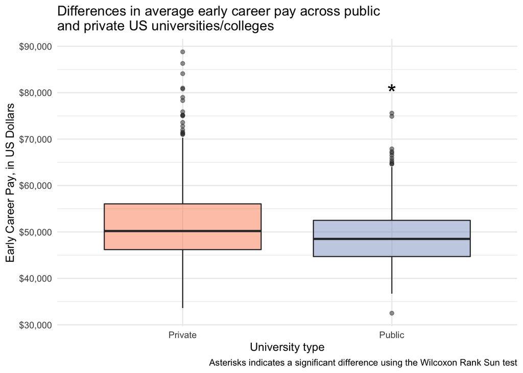

```r
salary_cost_join %>%
  drop_na(type, early_career_pay) %>%
  filter(type %in% c("Private", "Public")) %>%
  ggplot(aes(x = type, y = early_career_pay, fill = type)) +
  geom_boxplot(alpha = 0.5) +
  scale_y_continuous(labels = dollar) +
  scale_fill_manual(values = c("#fc8d62", "#8da0cb")) +
  annotate(geom = "text", x = 2, y = 80000, label = "*", size = 8) +
  theme_minimal() +
  theme(legend.position = "none") +
  labs(x = "University type",
       y = "Early Career Pay, in US Dollars",
       title = "Differences in average early career pay across public \nand private US universities/colleges",
       caption = "Asterisks indicates a significant difference using the Wilcoxon Rank Sun test")
```

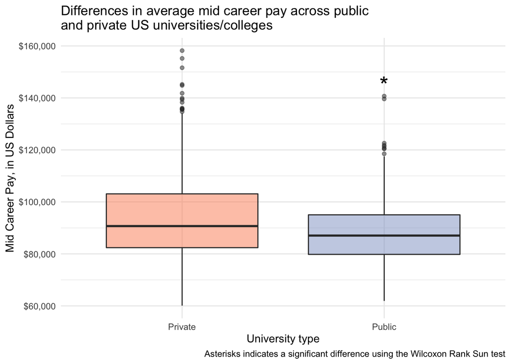

```r
salary_cost_join %>%
  drop_na(type, mid_career_pay) %>%
  filter(type %in% c("Private", "Public")) %>%
  ggplot(aes(x = type, y = mid_career_pay, fill = type)) +
  geom_boxplot(alpha = 0.5) +
  scale_y_continuous(labels = dollar) +
  scale_fill_manual(values = c("#fc8d62", "#8da0cb")) +
  annotate(geom = "text", x = 2, y = 145000, label = "*", size = 8) +
  theme_minimal() +
  theme(legend.position = "none") +
  labs(x = "University type",
       y = "Mid Career Pay, in US Dollars",
       title = "Differences in average mid career pay across public \nand private US universities/colleges",
       caption = "Asterisks indicates a significant difference using the Wilcoxon Rank Sun test")
```

#### With geom_text()

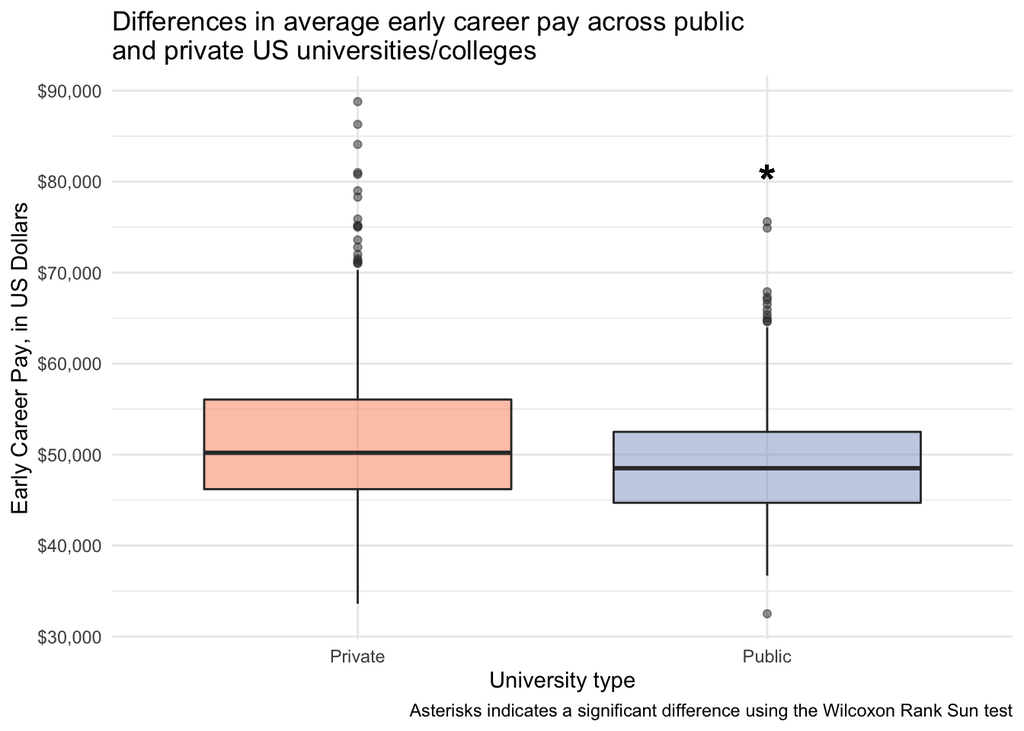

```r
salary_cost_join %>%
  drop_na(type, early_career_pay) %>%
  filter(type %in% c("Private", "Public")) %>%
  ggplot(aes(x = type, y = early_career_pay, fill = type)) +
  geom_boxplot(alpha = 0.5) +
  scale_y_continuous(labels = dollar) +
  scale_fill_manual(values = c("#fc8d62", "#8da0cb")) +
  geom_text(aes(x = 2, y = 80000, label = "*"), size = 8) +
  theme_minimal() +
  theme(legend.position = "none") +
  labs(x = "University type",
       y = "Early Career Pay, in US Dollars",
       title = "Differences in average early career pay across public \nand private US universities/colleges",
       caption = "Asterisks indicates a significant difference using the Wilcoxon Rank Sun test")
```

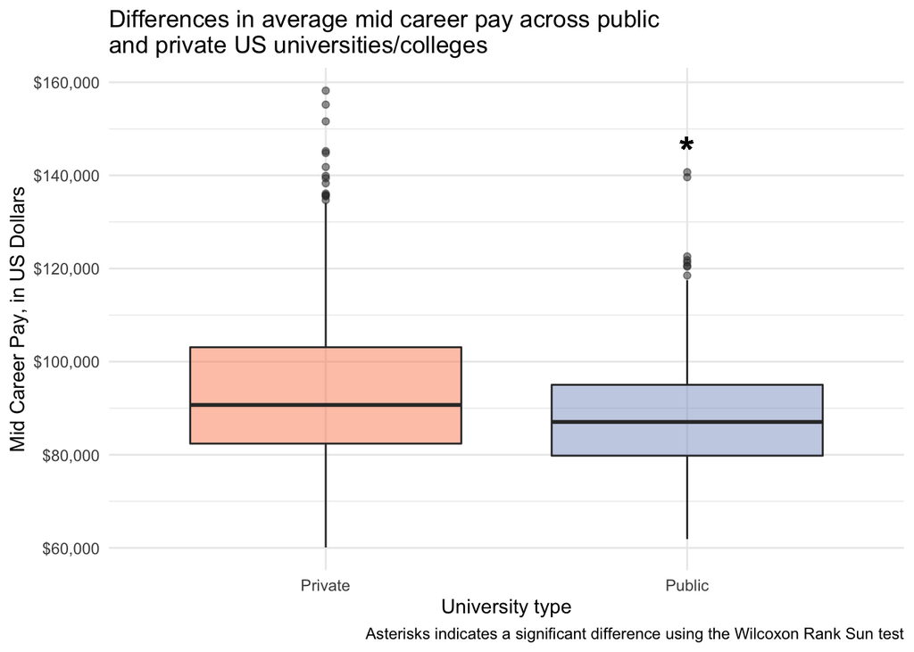

```r
salary_cost_join %>%
  drop_na(type, mid_career_pay) %>%
  filter(type %in% c("Private", "Public")) %>%
  ggplot(aes(x = type, y = mid_career_pay, fill = type)) +
  geom_boxplot(alpha = 0.5) +
  scale_y_continuous(labels = dollar) +
  scale_fill_manual(values = c("#fc8d62", "#8da0cb")) +
  geom_text(aes(x = 2, y = 145000, label = "*"), size = 8) +
  theme_minimal() +
  theme(legend.position = "none") +
  labs(x = "University type",
       y = "Mid Career Pay, in US Dollars",
       title = "Differences in average mid career pay across public \nand private US universities/colleges",
       caption = "Asterisks indicates a significant difference using the Wilcoxon Rank Sun test")
```

## 3. Understanding correlations visualization (3 pts)

Make a visualization that investigates and then visualizes correlation between `early_career_pay`, `mid_career_pay` and university tuition (both in state and out of state) showing correlation coefficients. Show how this is different across public and private universities. If you feel like you want to make a couple plots to display this relationship, that is fine.

### Wrangling

```r
# create matrix for correlation
to_rcorr_public <- salary_cost_join %>%
  filter(type == "Public") %>%
  select(in_state_tuition, out_of_state_tuition, early_career_pay, mid_career_pay) %>%
  drop_na() %>%
  as.matrix() # rcorr() needs a matrix

# create matrix for correlation
to_rcorr_private <- salary_cost_join %>%
  filter(type == "Private") %>%
  select(in_state_tuition, out_of_state_tuition, early_career_pay, mid_career_pay) %>%
  drop_na() %>%
  as.matrix() # rcorr() needs a matrix
```

### Create correlation matrix with pvalues.

```r
# create a correlation matrix that includes the pvalues for the correlations
public_rcorr <- rcorr(to_rcorr_public, type = "pearson")
private_rcorr <- rcorr(to_rcorr_private, type = "pearson")
```

### Get labels set up

```r
# create a vector of the alkaloid names for labeling
axis_labels <- c("In state tuition",
                 "Out of state tuition",
                 "Early career pay",
                 "Mid career pay")

# change row and column names of the correlation matrix
# so they are how we want them to be plotted
colnames(public_rcorr$r) <- axis_labels
rownames(public_rcorr$r) <- axis_labels
colnames(private_rcorr$r) <- axis_labels
rownames(private_rcorr$r) <- axis_labels

# change row and column names of the pvalue matrix
# so they are how we want them to be plotted
colnames(public_rcorr$P) <- axis_labels
rownames(public_rcorr$P) <- axis_labels
colnames(private_rcorr$P) <- axis_labels
rownames(private_rcorr$P) <- axis_labels
```

### Plot

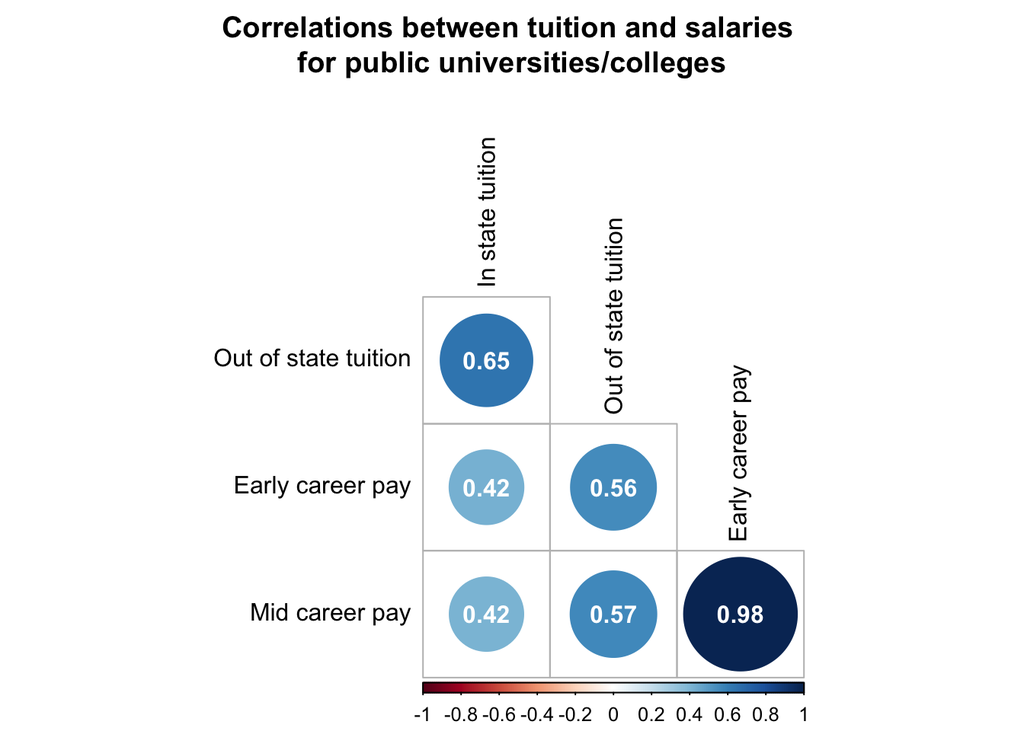

```r
# plot public
corrplot(public_rcorr$r, # the correlation matrix
         type = "lower", # lower triangle
         tl.col = "black", # axis labels are black
         p.mat  = public_rcorr$P, # pvalue matrix
         sig.level = 0.05, # how sig does a cor need to be to be included
         insig = "blank", # do not display insignificant correlations
         addCoef.col = "white", # display correlations in black
         diag = FALSE, # don't show the diagonal (because this is all 1)
         number.cex = 1, # size of correlation font
         title = "Correlations between tuition and salaries \nfor public universities/colleges", # indicate title
         mar=c(0,0,3,0)) # move title down
```

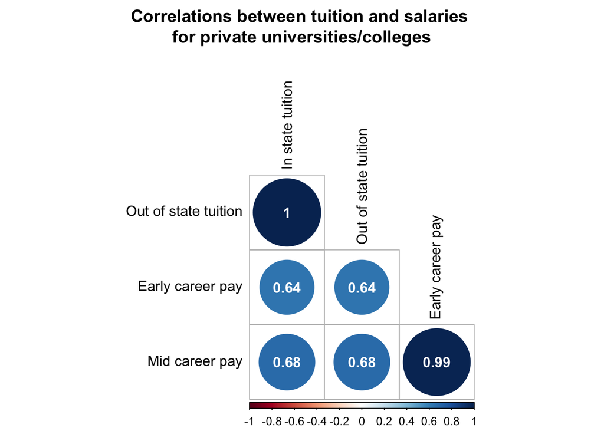

```r
# plot private
corrplot(private_rcorr$r, # the correlation matrix
         type = "lower", # lower triangle
         tl.col = "black", # axis labels are black
         p.mat  = private_rcorr$P, # pvalue matrix
         sig.level = 0.05, # how sig does a cor need to be to be included
         insig = "blank", # do not display insignificant correlations
         addCoef.col = "white", # display correlations in black
         diag = FALSE, # don't show the diagonal (because this is all 1)
         number.cex = 1, # size of correlation font
         title = "Correlations between tuition and salaries \nfor private universities/colleges", # indicate title
         mar=c(0,0,3,0)) # move title down
```